# Lecture 1 - Git basics & SQL basics

1. Git & Github introduction
2. Database basics and SQL introduction
3. Resource and homework

## Git & Github introduction

### What is Git & Github?

**Git is a version control tool for codes filing, collaborating and version control. It is widely used by data analytics community. Github is a great platform for us to show and share our own work & projects with the world.**

To understand GitHub, we must first have an understanding of Git. Git is an open-source version control system. Git is similar to other version control systems—Subversion, CVS, and Mercurial to name a few.

So, Git is a version control system, but what does that mean? When developers create something (an app, for example), they make constant changes to the code, releasing new versions up to and after the first official (non-beta) release.

Version control systems keep these revisions straight, storing the modifications in a central repository. This allows developers to easily collaborate, as they can download a new version of the software, make changes, and upload the newest revision. Every developer can see these new changes, download them, and contribute.

Similarly, people who have nothing to do with the development of a project can still download the files and use them. Most Linux users should be familiar with this process, as using Git, Subversion, or some other similar method is pretty common for downloading needed files—especially in preparation for compiling a program from source code (a rather common practice for Linux geeks).

Git is the preferred version control system of most developers, since it has multiple advantages over the other systems available. It stores file changes more efficiently and ensures file integrity better. If you’re interested in knowing the details, the Git Basics page has a thorough explanation on how Git works.

### Installing Git

[Git download](https://git-scm.com/downloads)

[figure not shown]

### Git commands

- Clone a Github repository
1. Browse to your local directory for this project
2. Right click. Open "Git Bash"
3. _git clone https://github.com/ronozh/data_science_and_engineering.git_

You have successfully download the Github repository to your local drive

- Set up your own Github repository
1. Go to your Github homepage
2. Create new project
3. Name the repository e.g. SQL_code

[figure not shown]

- More Git commands
1. *Git status* -- Check your Git status
2. *Git add filename* -- Add a file for staging
3. *Git add ** -- Add all the files for the staging
4. *Git commit -a* -- Commit all the files for staging
5. *Git push* -- Push all the staged changes to remote (origin) master
6. *Git pull* -- Pull any new updates from remote (origin) master to local branch

There are more [Git commands](https://github.github.com/training-kit/downloads/github-git-cheat-sheet.pdf), but the above should be more than enough to kick off.

- Practice
1. Check if your local Git repo is up to date.
2. Add a dummy file into your local Git repo, commit this file with a message "add a dummy file"
3. Push this change to the origin master.
4. From your Github homepage, upload another dummy file or make some changes.
5. Check if your local Git repo is up to date. If not, pull the changes from origin to local.
6. Once the above is all done, set up four folders in your local Git directory, SQL_code, R_code, Python_code, Projects. Push the updates to origin master.

**Congratulations! You now know how to manage your own data analytics codes & projects via Git!**

## Database basics and SQL introduction

### What is database & SQL?

A **database** is a collection of information that is organized so that it can be easily accessed, managed and updated. Data is organized into rows, columns and tables, and it is indexed to make it easier to find relevant information. Data gets updated, expanded and deleted as new information is added. Databases process workloads to create and update themselves, querying the data they contain and running applications against it.

A **relational database** is a tabular database in which data is defined so that it can be reorganized and accessed in a number of different ways. Relational databases are made up of a set of tables with data that fits into a predefined category. Each table has at least one data category in a column, and each row has a certain data instance for the categories which are defined in the columns.

The **Structured Query Language (SQL)** is the standard user and application program interface for a relational database. Relational databases are easy to extend, and a new data category can be added after the original database creation without requiring that you modify all the existing applications.

### Common SQL database

They share the main SQL syntax. It would be a small effort to master all of these if you can code main SQL.

1. ORACLE
2. TERADATA
3. SQL SERVER
4. MYSQL
5. POSTGRESQL

### SQL basic

Master SQL query keywords for most of the common queries!

**SELECT** (DISTINCT) CONCAT(), COUNT(), SUM(), LENGTH(), MAX(), MIN(), AVG(), CASE WHEN... THEN... ELSE.. END AS

**FROM**

**WHERE**

**GROUP BY** **HAVING**

**ORDER BY (DESC)**

operators:

**+, -, *, /, =, <, >, NOT, AND (&), OR (|), IN, LIKE, BETWEEN ... AND ...**

Refer to [w3schools](https://www.w3schools.com/sql/sql_intro.asp) for more SQL operations.

### SQL practice

Go to [w3schools](https://www.w3schools.com/sql/trysql.asp?filename=trysql_op_in) online SQL tool, do the following tasks.

1. Select all the products in product category 1. How many in total?
2. Select all the customers from France. Out of those, how many are at Paris?
3. How many orders are placed during 1996-07-01 and 1996-07-31?
4. Which employee graduated from University of Washington?
5. How many orders does each product ID has? What are the total quantity for each product? What is the average quantity per order per product?
6. How many different products are in each order? Which order has the most number of unique products?
7. Which products are sold in jars? What is the most expensive product that's sold in jars?
8. What are the product names are included in order ID 10250?
9. What products are contained in category 'Dairy Products'?

### SQL join

When two or more tables have at least one common column.key, we can join these tables to match the rows. So that, we can map the columns of the two tables.

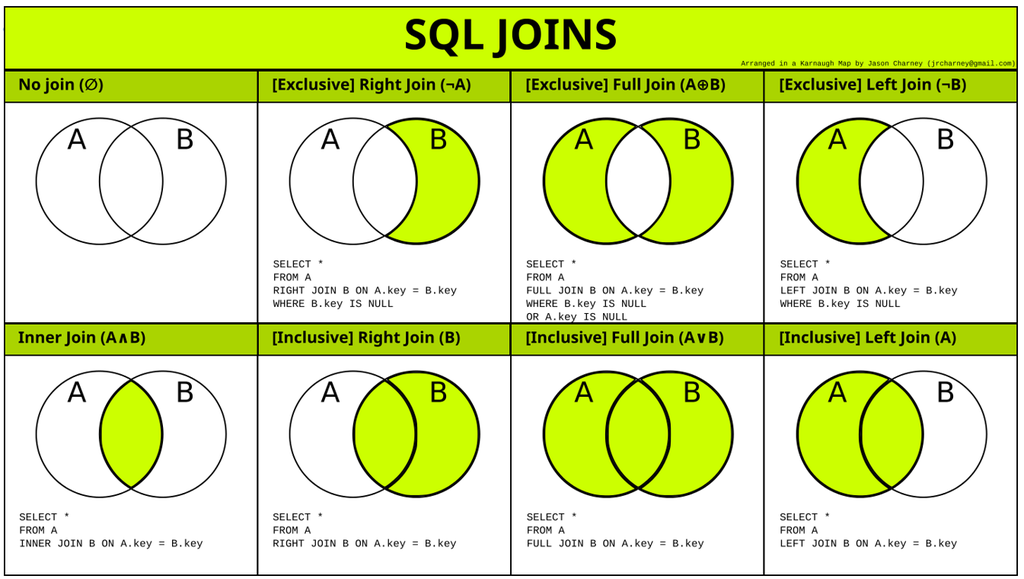

### Join practice

1. How many orders are made by Germany customers in total?
2. How many orders are made by Germany customers that's shipped by shipper 2 in total?
3. Are there any prepared meats products are supplied by Tokyo Traders?

### Installing MySQL server

We will use MySQL for most of the SQL learnings and practice in this course. It is a very popular server that is used by many firms around the world.

[figure not shown]

### MySQL workbench

For most of the time, we use MySQL workbench in buiness enviroment. Regardless what SQL servers, you would use a query editor that's similar to Mysql workbench.

[figure not shown]

### Introducing MySQL database

We will use Sakila database for our SQL learning tasks.

The **Sakila** sample database was initially developed by Mike Hillyer, a former member of the MySQL AB documentation team, and is intended to provide a standard schema that can be used for examples in books, tutorials, articles, samples, and so forth. Sakila sample database also serves to highlight the latest features of MySQL such as Views, Stored Procedures, and Triggers.

The Sakila database is a nicely normalised schema modelling a DVD rental store, featuring things like films, actors, film-actor relationships, and a central inventory table that connects films, stores, and rentals.

If your Mysql does not have Sakila, please follow the [instructions](https://dev.mysql.com/doc/sakila/en/sakila-installation.html) to install it.

### Sakila database structure

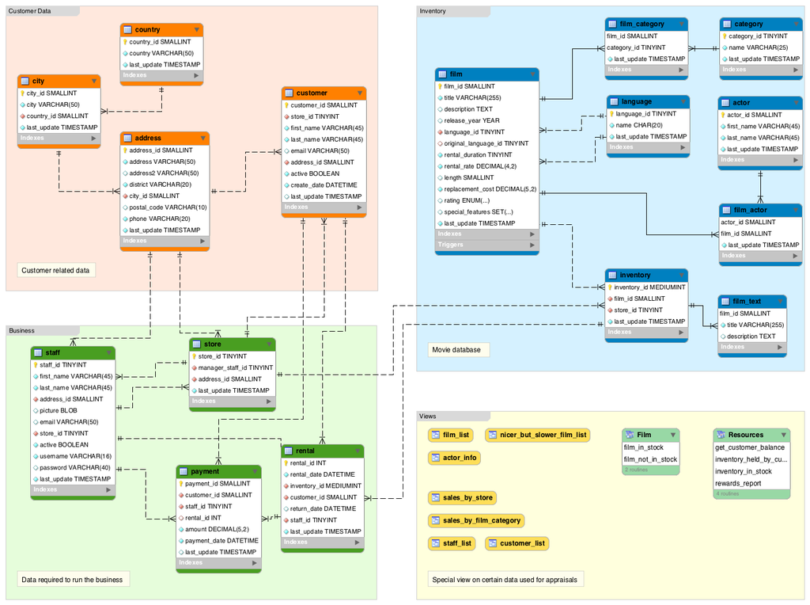

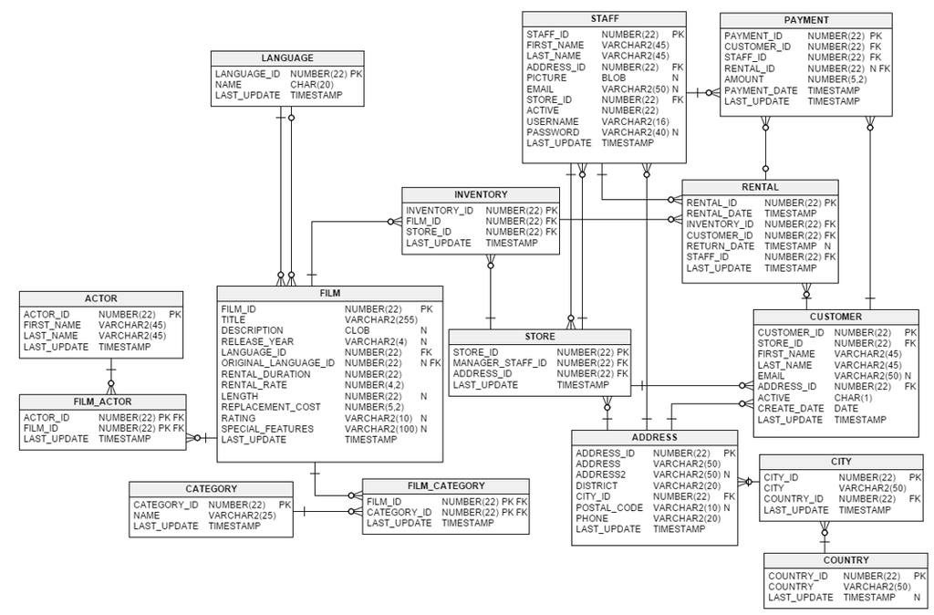

### Sakila practice

#### basic select

1. Which actors have the first name 'Scarlett'?
2. Which actors have the last name 'Johansson'
3. How many distinct actors last names are there?
4. Which last names appear more than once?
5. How many total rentals occured in May?
6. How many staff processed rentals in May?
7. Which staff processed the most rentals in May?
8. Which customer paid the most rental in August?
9. A summary of rental total amount by month.

#### table joins

1. Which actor has appeared in the most films?
2. Use JOIN to display the first and last names, as well as the address, of each staff member. Use the tables staff and address.
3. List each film and the number of actors who are listed for that film. Use tables film_actor and film. Use inner join.
4. How many copies of the film Hunchback Impossible exist in the inventory system?
5. Using the tables payment and customer and the JOIN command, list the total paid by each customer. List the customers alphabetically by last name:

## Resource and homework

1. Read and always refer to [W3school](https://www.w3schools.com/sql/) SQL tutorial
2. Data camp - [Intro to SQL for data science](https://www.datacamp.com/courses/intro-to-sql-for-data-science) (2-5h)
3. Sakila query practice (3h)
4. [R](https://www.r-project.org/)/[Rstudio](https://rstudio.com/products/rstudio/download/#download) installation
5. [Anaconda](https://www.anaconda.com/distribution/) installation

Optional:

1. Data camp - [Joining data in SQL]https://www.datacamp.com/courses/joining-data-in-postgresql (2-5h)
2. Data camp - [Analyzing Business Data in SQL](https://www.datacamp.com/courses/analyzing-business-data-in-sql) (1-4h)